# 8_1_X11_SEATS_STL

Juan Garbayo

3/3/2022

# References TODO: FIX REFERENCES

1. Hyndman, R.J., & Athanasopoulos, G., 2021. *Forecasting: principles and practice*. 3rd edition.
2. Dagum, E. B., & Bianconcini, S. (2016). Seasonal adjustment methods and real time trend-cycle estimation. Springer.
3. https://www2.census.gov/software/x-13arima-seats/x-13-data/documentation/docx13as.pdf
4. https://feasts.tidyverts.org/reference/X_13ARIMA_SEATS.html
5. http://www.seasonal.website/seasonal.html
6. Cleveland, R. B., Cleveland, W. S., McRae, J. E., & Terpenning, I. J. (1990). STL: A seasonal-trend decomposition procedure based on loess. Journal of Official Statistics, 6(1), 3–33.
7. Local Regression: https://en.wikipedia.org/wiki/Local_regression
8. https://www.theguardian.com/news/datablog/2014/oct/09/abs-jobs-and-unemployment-figures-key-questions-answered-by-an-expert

# Packages

```r
library(fpp3)
library(seasonal)
```

# Introduction

Statistical agencies (e.g. US Census Bureau and the Australian Bureau of Statistics) develop and mantain a number of official time series methods that standardize analyses. They have developed their own decomposition procedures which are used for seasonal adjustment. Most of these methods use the X-11 method, the SEATS method or a combination of the two.

We will discuss now the X-11 method, the SEATS method and the STL method.

For the methods discussed now, you will need to have installed the `seasonal` package in R (see reference [5]).

# Shortcomings of the classical decomposition method

- No estimate of the trend-cycle or the remainder for the first few and last observations
- Seasonal component repeats from year to year (remains constant)
- Not robust enough against unusual values or outliers in the series.

# X-11 Method

Based on classical decomposition but includes many extra steps and features in order to overcome the drawbacks of classical decomposition.

A good introduction to the details of this method of seasonal adjustment (beyond the scope of the course) can be found in ref [2], section 4.1.1.

## X-11 - Advantages

- Trend-cycle estimates are available for all observations (including end-points).
- Seasonal component is allowed to vary slowly over time.
- Completely automated choices for trend and seasonal changes.
- Relatively robust to outliers and level shifts in the time series.
- Handles (see definitions at the end of the notebook).
  - **Trading day effects**
  - **Holiday factors can be estimated**

## X-11 - Shortcomings

- Developed **only for quarterly and monthly data.**
  - Do not handle other seasonality (daily, hourly, weekly…)
  - Most common data used by statistical agencies.

## X-11 Documentation

We will use the X11 procedure for seasonal adjustment through the `X_13ARIMA_SEATS()` function from the `feasts` package (reference [4]). This function is a somewhat simplified interface to use the `seasonal` package (reference [5]), which is an R-interface for the X-13ARIMA-SEATS model as implemented by the U.S. Census Bureau (reference [3]).

The details about the arguments to the function are best specified in [3] (section 7).

## X-11 Example

Below a simple example of how to use the X11. Have a look at the above references mentioned under the section X-11 Documentation for a more advanced use of the options available:

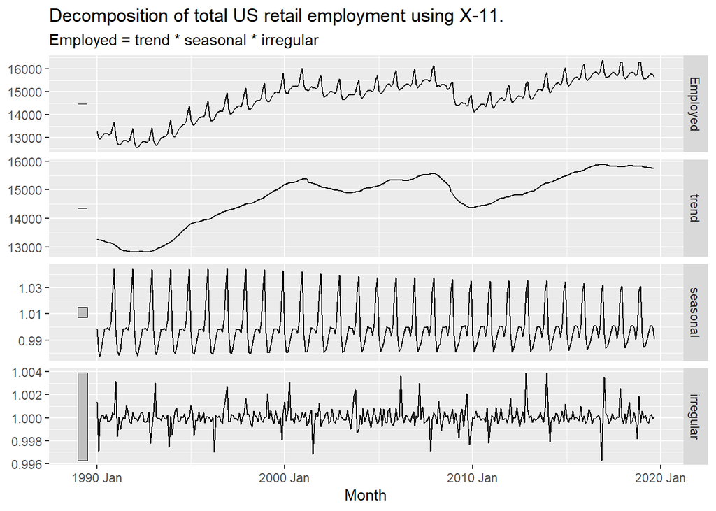

```r
# Extraction of the us_retail_employment series
us_retail_employment <- us_employment %>%
  filter(year(Month) >= 1990, Title == "Retail Trade") %>%
  select(-Series_ID)

x11_dcmp <- us_retail_employment %>%
  model(x11 = X_13ARIMA_SEATS(Employed ~ x11())) %>%
  components()
autoplot(x11_dcmp) +
  labs(title =
    "Decomposition of total US retail employment using X-11.")
```

### X-11 Variation of the seasonal component over time

Since now the seasonal component is allowed to slowly change over time, it can be helpful to visualize its variation over time:

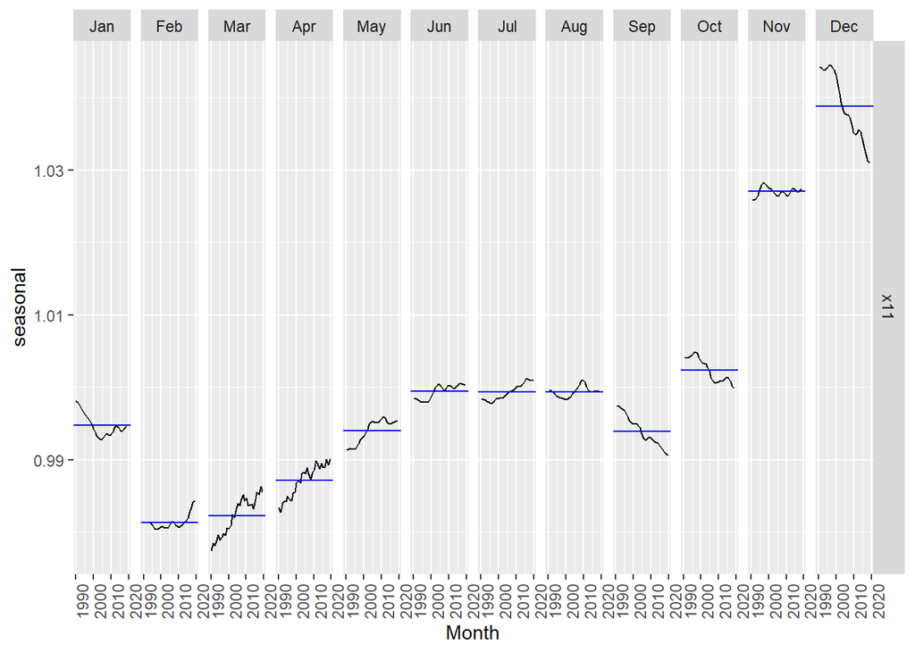

```r
x11_dcmp %>%
  gg_subseries(seasonal)
```

- Most seasonal components remain relatively stable over time.
- December experiences the great seasonal variation.

## Defining arguments for the X11-decomposition

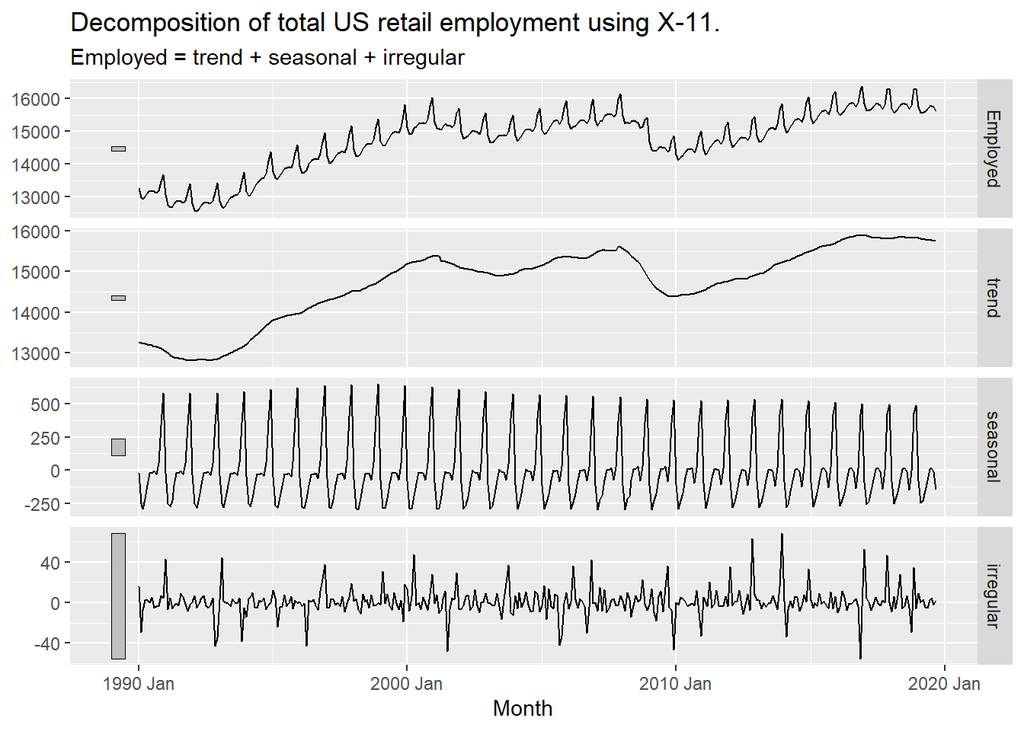

```r
x11_dcmp <- us_retail_employment %>%
  # transform(`function` = "none"): tells the model to not perform any transformation on the data
  # x11(`mode` = "add"): tells the model to use an additive rather than a multiplicative decomposition
  model(x11 = X_13ARIMA_SEATS(Employed ~ transform(`function` = "none") + x11(`mode` = "add"))) %>%
  components()
autoplot(x11_dcmp) +
  labs(title =
    "Decomposition of total US retail employment using X-11.")
```

## X-11 Exercise

1. Perform a decomposition of the retail series we used in the asynchronous session 4 using the X11 method.
2. Depict the variation of the seasonal components over time using a gg_subseries().

```
## Plot variable not specified, automatically selected `.vars = Turnover`
```

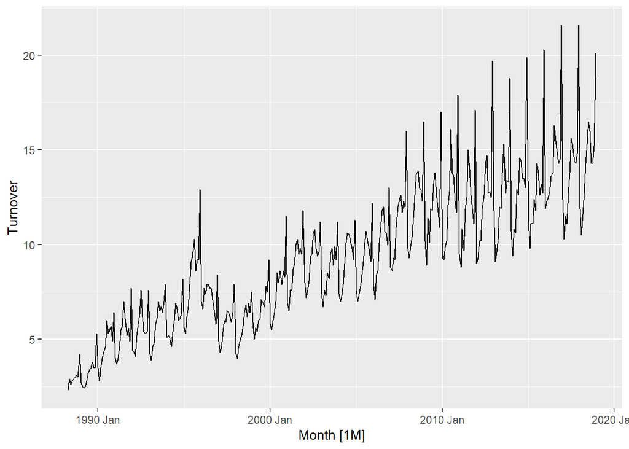

```r
retail_series <- aus_retail %>%
  filter(`Series ID` == "A3349767W")

autoplot(retail_series)
```

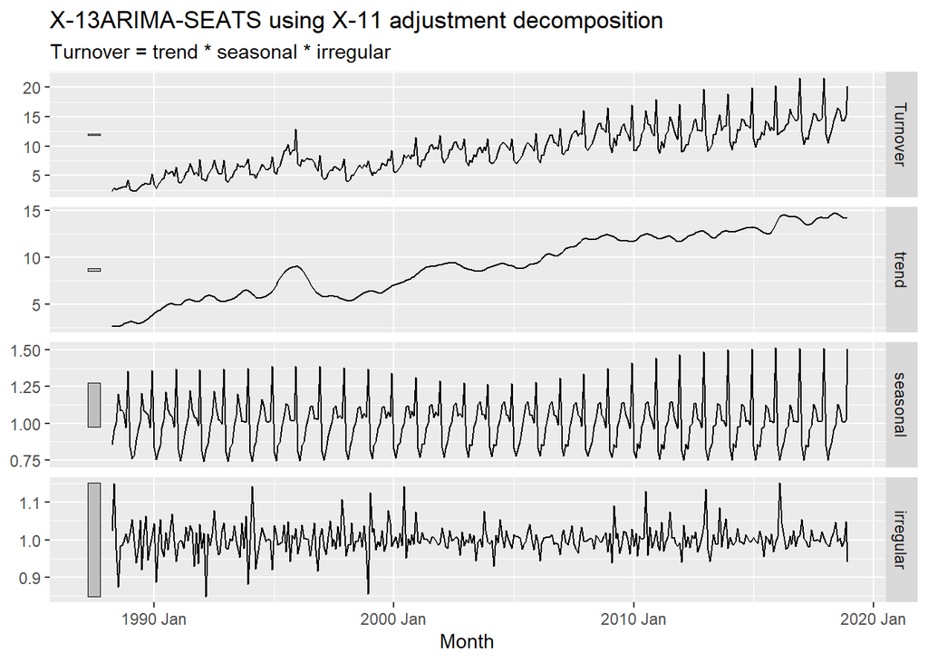

```r
decomp <- retail_series %>%
  model(x11 = X_13ARIMA_SEATS(Turnover ~ x11())) %>%
  components()
decomp %>% autoplot()
```

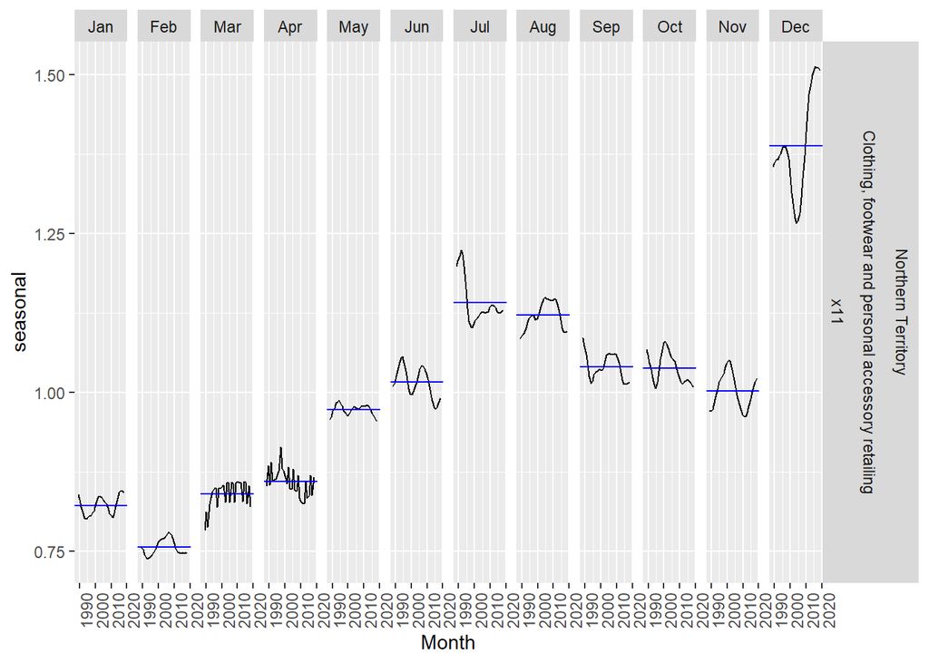

```r
decomp %>%
  gg_subseries(seasonal)
```

# SEATS

Stands for “Seasonal Extraction in ARIMA Time Series” (ARIMA models have not been discussed yet).

## SEATS advantages and shortcomings

Same as for X-11 decomposition

## SEATS Documentation

We will use the SEATS procedure for seasonal adjustment through the `X_13ARIMA_SEATS()` function from the `feasts` package (reference [4]). This function is a somewhat simplified interface to use the `seasonal` package (reference [5]), which is an R-interface for the X-13ARIMA-SEATS model as implemented by the U.S. Census Bureau (reference [3]).

The details about the arguments to the function are best specified in ref [3] (section 7).

## SEATS example

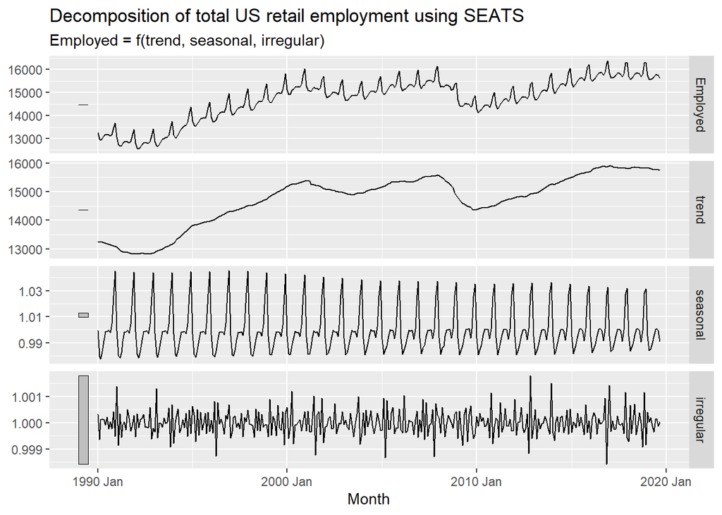

```r
seats_dcmp <- us_retail_employment %>%
  model(seats = X_13ARIMA_SEATS(Employed ~ seats())) %>%
  components()
autoplot(seats_dcmp) +
  labs(title =
    "Decomposition of total US retail employment using SEATS")
```

Note that the above decomposition is neither additive nor multiplicative, but rather a mixed model!

The SEATS algorithm has looked for an optimal solution and it turns out this algorithm works best with something that is neither additive or multiplicative.

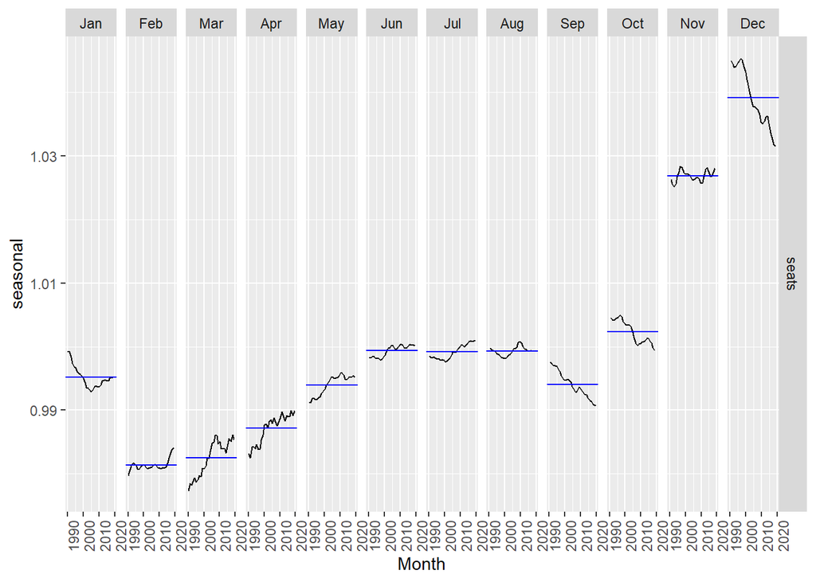

```r
seats_dcmp %>%
  gg_subseries(seasonal)
```

Results are quite similar to those obtained using the X-11 Method

## SEATS exercise

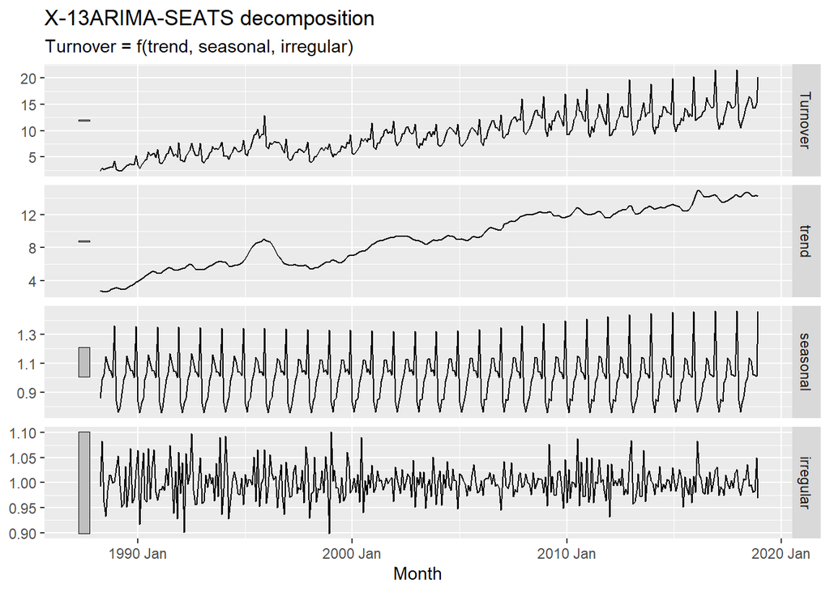

```r
retail_seats_decomp <- retail_series %>%
  model(x11 = X_13ARIMA_SEATS(Turnover ~ seats())) %>%
  components()
retail_seats_decomp %>% autoplot()
```

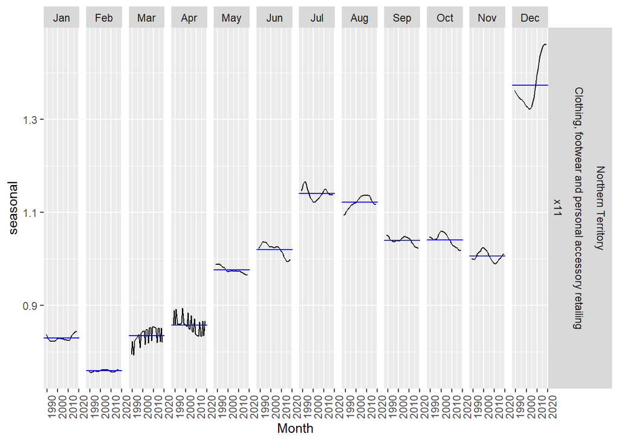

```r
retail_seats_decomp %>%
  gg_subseries(seasonal)
```

## STL

Acronym for *“Seasonal and Trend Decomposition using LOESS”*

**LOESS**: it is a method of **local regression** for estimating non-linear relationships. It stands for *LOcally Estimated Scatterplot Smoothing*.

The following is a cursory description of how a LOESS curve is computed:

- A positive integer $q < n$ is chosen (n = number of points)
- For each point $\bar{X}$, the q points of your data that are closest to that point are selected.
  - Each point is given a neighborhood weight based on its distance to $\bar{X}$.
  - The closest a point is to $\bar{X}$, the greater its weight.
- These weights are then used to fit a locally fit polinomial of degree $d$ to the data.
  - For STL $d$ = 1 or 2. That is, the fitting is locally-linear or locally-quadratic.

In summary, subsets of data used for each weighted least squares fit in LOESS are determined by a nearest neighbors algorithm. The data analyst is not required to specify a global function of any form to fit a model to the data, only to fit segments of the data.

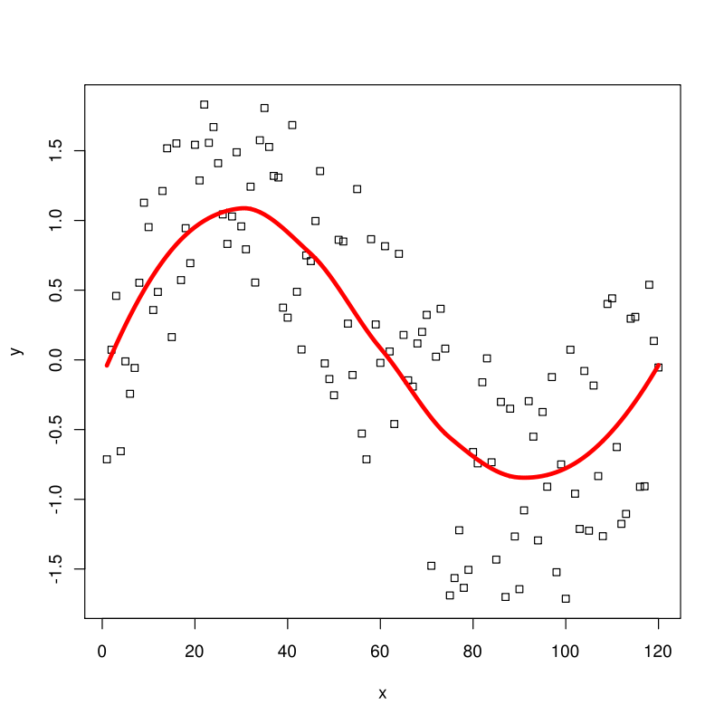

Using LOESS, the **STL algorithm** is capable of recursively approximating the components of the time series. For details on how this is achieved, refer to [6], section 2.1.

## STL Advantages:

- Handles any type of seasonallity (not only monthly or quarterly)
- Seasonal component allowed to change over time.
  - Rate of change can be controlled by the user.
- The smoothness of the trend-cycle can also be controlled by the user
- It can be robust to outliers

## STL Disadvantages:

- Does not handle trading day or calendar variation automatically.
- Only works for additive decompositions
  - Multiplicative schemes can be made additive with a log transformation.
  - Decompositions that are between additive and multiplicative can be obtained using a Box-Cox transformation
- It can be robust to outliers (i.e., the user can specify a robust decomposition), so that occasional unusual observations will not affect the estimates of the trend-cycle and seasonal components. They will, however, affect the remainder component.
- Might require user tuning to fit the LOESS windows

## STL main parameters:

- **Trend-cycle window** `trend(window = ?)`
  - Controls how rapidly the trend-cycle component changes.
  - Smaller values for more rapid changes.
  - Number of consecutive observations to be used when estimating the trend.
  - Must be an ODD number.
- **Seasonal-window** `season(window = ?)`
  - Controls how rapidly the seasonal component changes
  - Smaller values for more rapid changes.
  - Number of consecutive years to be used in estimating each value of the seasonal component.
  - Must be an ODD number.
  - `season(window='periodic')` sets the seasonal window to be infinite, which forces the seasonal component to be identical for every year.
- **Default values**
  - `season(window = 13)`. This usually provides a good balance between **overfitting the seasonality and allowing it to slowly change over time**.
  - `trend(window = 21)`

## STL Examples

```r
stl_dcmp_1 <- us_retail_employment %>%
  model(stl = STL(Employed)) %>%
  components()
```

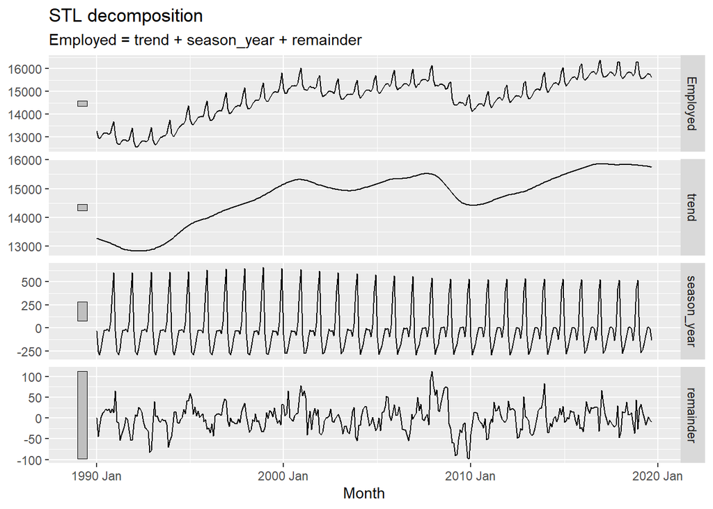

```r
stl_dcmp_1 %>% autoplot()
```